# Devoir 3

### Annexes

##### Figures exercice 1

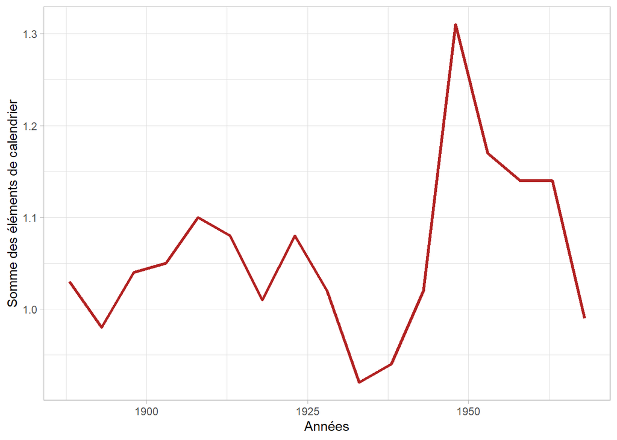

*Figure 1 : Somme des éléments de calendrier recensés entre 1886 et 1970*

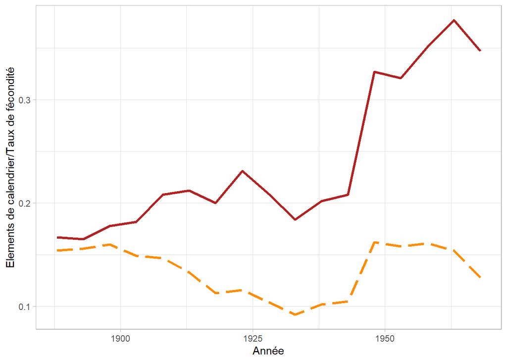

*Figure 2 : Elements de calendrier de 20-25 ans (en rouge plein) et taux de fécondité à 20-24 ans en années révolues recensés entre 1886 et 1970*

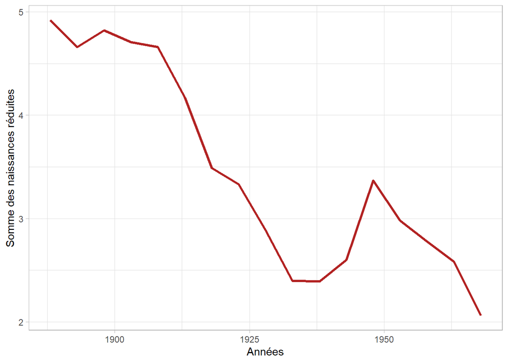

*Figure 3 : Evolution de la somme des naissances réduites pour 1 femme*

##### Figures exercice 2

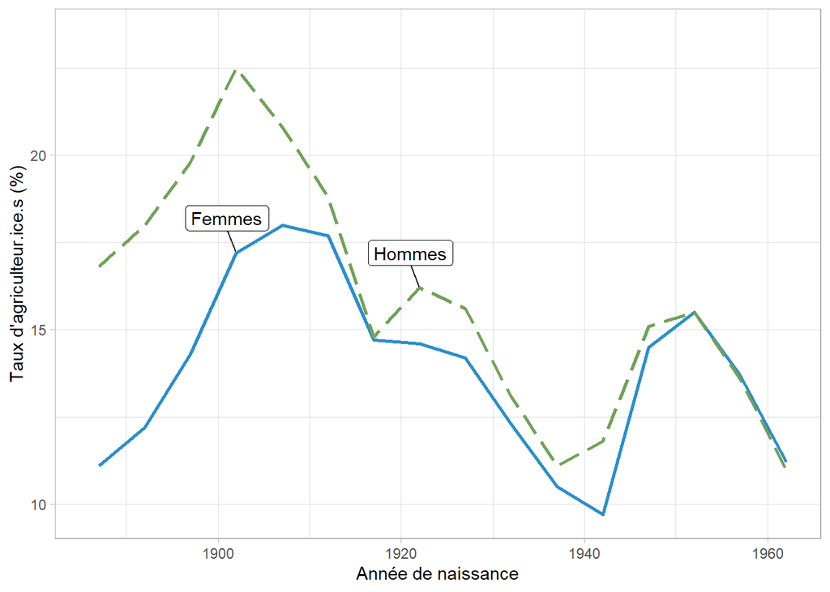

*Figure 4 : Taux de population vivant sur les exploitations agricoles au 1er Janvier 1964 par année de naissance et par sexe dans la population générale.*

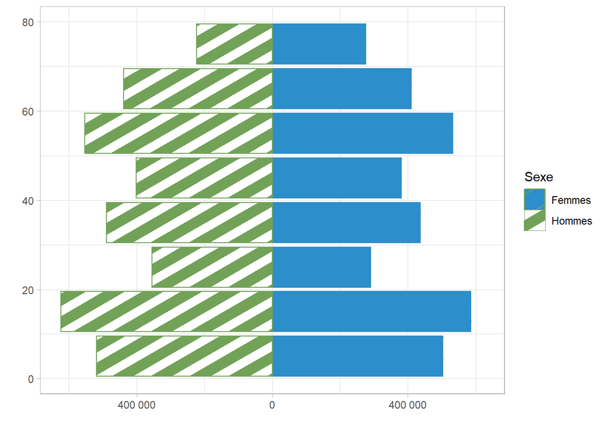

*Figure 5 : Pyramide des âges de la population vivant sur les exploitations agricoles au 1er Janvier 1964*